# Evaluating a Bayesian GSD: conjugate and non-conjugate priors

This vignette walks through the **evaluation** workflow of a Bayesian group sequential design: given a fixed design, prior and decision rule, estimate the operating characteristics by Monte Carlo simulation under a user-supplied data-generating effect. We work through two scenarios on the same binary ADRENAL re-design, differing only in the prior:

1. **Conjugate prior** — independent $\mathrm{Beta}(1, 1)$ priors on the per-arm response rates. Each per-arm posterior stays a single beta, and the risk-difference tail probability, which has no closed form, is evaluated by a fixed 64-node Gauss–Legendre quadrature at every look (no MCMC).
2. **Non-conjugate prior** — a logit-normal prior on the control-arm rate, approximated by a beta mixture via `fit_mixture()`. The same quadrature applies component-wise, so the per-look tail-probability cost scales with the number of mixture components.

The shared design and decision rule are constructed once.

```r
library(adabay)

des <- set_design(
  endpoint     = "binary",
  n_per_look   = c(760, 1520, 2280, 3040, 3800),
  effect_scale = "risk_difference",
  alternative  = "less"
)

dec <- set_decision(
  efficacy = list(list(threshold_effect = 0, threshold_prob = 0.99)),
  futility = list(list(threshold_effect = 0, threshold_prob = 0.90)),
  futility_binding = FALSE
)
```

Because `futility_binding = FALSE`, the futility boundary is **non-binding**: the reported Type I error rate (`$alpha`) is computed *as if the futility rule were ignored*, which is the regulatory convention, whereas the realised power under the actual trial conduct — in which the trial does stop at a futility crossing — is `$eff_prob`. The two coincide only under binding futility. We therefore read Type I error from `$alpha` and power from `$eff_prob` below.

# 1. Conjugate prior

The simplest case: independent $\mathrm{Beta}(1, 1)$ priors on the per-arm response rates.

```r
pri_conj <- set_prior(
  endpoint = "binary",
  arms = list(c = list(family = "beta", a = 1, b = 1),
              t = list(family = "beta", a = 1, b = 1))
)
pri_conj
```

```
#> Bayesian group sequential prior
#>   Endpoint: binary
#>   Control arm: family = beta, components = 1
#>     [1] weight = 1.000, a = 1, b = 1
#>   Treatment arm: family = beta, components = 1
#>     [1] weight = 1.000, a = 1, b = 1
```

We evaluate the operating characteristics under both the null ($\theta_c = \theta_t = 0.33$) and the alternative ($\theta_c = 0.33$, $\theta_t = 0.28$), with `n_trials = 2000` for a fast vignette. Raising this to `n_trials = 1e6` recovers the manuscript precision.

```r
oc_conj_h0 <- evaluate_design(
  des, pri_conj, dec,
  effect   = list(theta_c = 0.33, theta_t = 0.33),
  n_trials = 2000, cores = 1, seed = 1L
)
oc_conj_h1 <- evaluate_design(
  des, pri_conj, dec,
  effect   = list(theta_c = 0.33, theta_t = 0.28),
  n_trials = 2000, cores = 1, seed = 1L
)

cat(sprintf("Conjugate Beta(1,1) prior:\n"))
```

```
#> Conjugate Beta(1,1) prior:
```

```r
cat(sprintf("  Type I error rate  = %.2f%%\n", 100 * oc_conj_h0$alpha))
```

```
#>   Type I error rate  = 3.35%
```

```r
cat(sprintf("  Power              = %.2f%%\n", 100 * oc_conj_h1$eff_prob))
```

```
#>   Power              = 87.70%
```

```r
cat(sprintf("  E(N | H1)          = %.0f patients\n",
            oc_conj_h1$expected_sample_size))
```

```
#>   E(N | H1)          = 2209 patients
```

The per-look stopping probabilities and the bar chart show where the trial accumulates efficacy and futility mass.

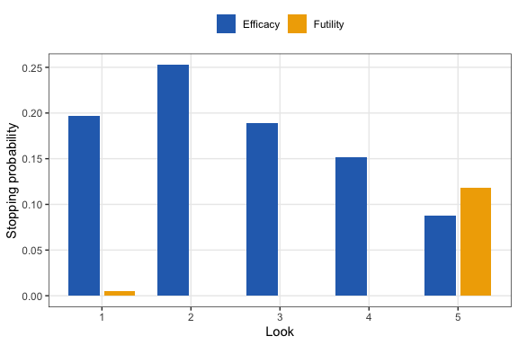

```r
if (requireNamespace("ggplot2", quietly = TRUE)) plot(oc_conj_h1)
```

# 2. Non-conjugate prior approximated by a beta mixture

Suppose the prior on the control-arm rate $\theta_c$ is summarised by a logit-normal with logit-scale mean $-0.7$ and standard deviation $0.4$, corresponding to a prior median near $0.33$ and modest spread. A logit-normal is not conjugate to the binomial, so we approximate it by a finite mixture of beta components via `fit_mixture()`. The treatment-arm prior remains $\mathrm{Beta}(1, 1)$.

Because `prior` is supplied here as a density function rather than a vector of pre-drawn samples, `fit_mixture()` draws `n_samples` observations from it internally; passing `seed` makes that draw (and hence the fitted mixture) reproducible regardless of what randomness this session has already consumed, rather than depending on the ambient RNG state.

```r
logit_normal_density <- function(theta) {
  meanlog <- -0.7
  sdlog   <-  0.4
  z <- log(theta / (1 - theta))
  dnorm(z, meanlog, sdlog) / (theta * (1 - theta))
}

pri_c_arm <- fit_mixture(
  endpoint         = "binary",
  arm              = "c",
  prior            = logit_normal_density,
  n_components_max = 5L,
  tol_kl           = 1e-3,
  tol_tail         = 5e-3,
  n_samples        = 10000L,
  seed             = 1L
)
pri_c_arm
```

```
#> Fitted conjugate-mixture prior arm 'c'
#>   Kernel family:        beta
#>   Mixture components:   2
#>     [1] weight = 0.430, a =  12.8, b = 31.47
#>     [2] weight = 0.570, a = 12.23, b = 20.47
#>   Method:               RBesT::automixfit
#>   Forward KL (samples): 0.00070
#>   Max |tail error|:     0.0034 (tol = 0.0050)
#>   Seed:                 1
#>   Per-quantile tail-probability table:
#>     q=0.025  threshold=0.183  P_empirical=0.0250  P_mixture=0.0242  error=-0.0008
#>     q=0.050  threshold=0.2036  P_empirical=0.0500  P_mixture=0.0500  error=-0.0000
#>     q=0.100  threshold=0.2281  P_empirical=0.1000  P_mixture=0.0996  error=-0.0004
#>     q=0.500  threshold=0.3308  P_empirical=0.5000  P_mixture=0.4966  error=-0.0034
#>     q=0.900  threshold=0.4554  P_empirical=0.9000  P_mixture=0.9002  error=+0.0002
#>     q=0.950  threshold=0.4919  P_empirical=0.9500  P_mixture=0.9509  error=+0.0009
#>     q=0.975  threshold=0.5231  P_empirical=0.9750  P_mixture=0.9759  error=+0.0009
```

```r
pri_nc <- set_prior(
  endpoint = "binary",
  arms     = list(c = pri_c_arm,
                  t = list(family = "beta", a = 1, b = 1))
)
```

`fit_mixture()` reports per-quantile tail-probability errors and emits a runtime warning when the maximum absolute error exceeds `tol_tail`. The overlay plot below compares the empirical-sample density against the fitted mixture density, with vertical rugs at the tail-quantile grid.

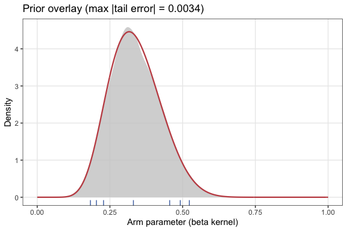

```r
if (requireNamespace("ggplot2", quietly = TRUE)) plot(pri_c_arm)
```

The downstream evaluation is identical to the conjugate case — there is no change in user-facing code beyond passing `pri_nc` instead of `pri_conj`.

```r
oc_nc_h0 <- evaluate_design(
  des, pri_nc, dec,
  effect   = list(theta_c = 0.33, theta_t = 0.33),
  n_trials = 2000, cores = 1, seed = 1L
)
oc_nc_h1 <- evaluate_design(
  des, pri_nc, dec,
  effect   = list(theta_c = 0.33, theta_t = 0.28),
  n_trials = 2000, cores = 1, seed = 1L
)

cat(sprintf("Non-conjugate (logit-normal) prior via beta mixture:\n"))
```

```
#> Non-conjugate (logit-normal) prior via beta mixture:
```

```r
cat(sprintf("  Type I error rate  = %.2f%%\n", 100 * oc_nc_h0$alpha))
```

```
#>   Type I error rate  = 3.15%
```

```r
cat(sprintf("  Power              = %.2f%%\n", 100 * oc_nc_h1$eff_prob))
```

```
#>   Power              = 87.80%
```

```r
cat(sprintf("  E(N | H1)          = %.0f patients\n",
            oc_nc_h1$expected_sample_size))
```

```
#>   E(N | H1)          = 2215 patients
```

# 3. Side-by-side comparison

```r
data.frame(
  prior     = c("Beta(1,1) flat", "logit-normal mixture"),
  type_I_pp = c(100 * oc_conj_h0$alpha, 100 * oc_nc_h0$alpha),
  power_pp  = c(100 * oc_conj_h1$eff_prob, 100 * oc_nc_h1$eff_prob),
  E_N_H1    = c(oc_conj_h1$expected_sample_size,
                oc_nc_h1$expected_sample_size)
)
```

```
#>                  prior type_I_pp power_pp  E_N_H1
#> 1       Beta(1,1) flat      3.35     87.7 2208.56
#> 2 logit-normal mixture      3.15     87.8 2215.02
```

# Summary

`evaluate_design()` is the same call for the conjugate and the non-conjugate case; only the `adabay_prior` object differs. The mixture approximation enters the pipeline exactly once, when constructing the `adabay_prior_arm` object via `fit_mixture()`, after which every downstream entry point runs at full conjugate speed.